# Risk Factor Analysis

## Outcome Variable

**Outcome Variable:** y_rate_len

## Predictor Variables

**Intervention Variable:** nhh

**Adjustment Set:**

unadjusted

## Stratifying Variables

The analysis was stratified on these variable(s):

- agecat
- studyid
- country

## Data Summary

| agecat | studyid | country | nhh | n_cell | n |
| --- | --- | --- | --- | --- | --- |
| 0-3 months | IRC | INDIA | 3 or less | 53 | 377 |
| 0-3 months | IRC | INDIA | 4-5 | 146 | 377 |
| 0-3 months | IRC | INDIA | 6-7 | 99 | 377 |
| 0-3 months | IRC | INDIA | 8+ | 79 | 377 |
| 0-3 months | NIH-Birth | BANGLADESH | 3 or less | 101 | 566 |
| 0-3 months | NIH-Birth | BANGLADESH | 4-5 | 239 | 566 |
| 0-3 months | NIH-Birth | BANGLADESH | 6-7 | 132 | 566 |
| 0-3 months | NIH-Birth | BANGLADESH | 8+ | 94 | 566 |
| 0-3 months | NIH-Crypto | BANGLADESH | 3 or less | 108 | 721 |
| 0-3 months | NIH-Crypto | BANGLADESH | 4-5 | 324 | 721 |
| 0-3 months | NIH-Crypto | BANGLADESH | 6-7 | 169 | 721 |
| 0-3 months | NIH-Crypto | BANGLADESH | 8+ | 120 | 721 |
| 0-3 months | PROVIDE | BANGLADESH | 3 or less | 123 | 640 |
| 0-3 months | PROVIDE | BANGLADESH | 4-5 | 296 | 640 |
| 0-3 months | PROVIDE | BANGLADESH | 6-7 | 136 | 640 |
| 0-3 months | PROVIDE | BANGLADESH | 8+ | 85 | 640 |
| 3-6 months | IRC | INDIA | 3 or less | 57 | 397 |
| 3-6 months | IRC | INDIA | 4-5 | 154 | 397 |
| 3-6 months | IRC | INDIA | 6-7 | 103 | 397 |
| 3-6 months | IRC | INDIA | 8+ | 83 | 397 |
| 3-6 months | NIH-Birth | BANGLADESH | 3 or less | 89 | 523 |
| 3-6 months | NIH-Birth | BANGLADESH | 4-5 | 223 | 523 |
| 3-6 months | NIH-Birth | BANGLADESH | 6-7 | 126 | 523 |
| 3-6 months | NIH-Birth | BANGLADESH | 8+ | 85 | 523 |
| 3-6 months | NIH-Crypto | BANGLADESH | 3 or less | 101 | 695 |
| 3-6 months | NIH-Crypto | BANGLADESH | 4-5 | 316 | 695 |
| 3-6 months | NIH-Crypto | BANGLADESH | 6-7 | 163 | 695 |
| 3-6 months | NIH-Crypto | BANGLADESH | 8+ | 115 | 695 |
| 3-6 months | PROVIDE | BANGLADESH | 3 or less | 104 | 598 |
| 3-6 months | PROVIDE | BANGLADESH | 4-5 | 285 | 598 |

[output cut: 138 more lines]

The following strata were considered:

- agecat: 0-3 months, studyid: IRC, country: INDIA
- agecat: 0-3 months, studyid: NIH-Birth, country: BANGLADESH
- agecat: 0-3 months, studyid: NIH-Crypto, country: BANGLADESH
- agecat: 0-3 months, studyid: PROVIDE, country: BANGLADESH
- agecat: 12-15 months, studyid: IRC, country: INDIA
- agecat: 12-15 months, studyid: LCNI-5, country: MALAWI
- agecat: 12-15 months, studyid: NIH-Birth, country: BANGLADESH
- agecat: 12-15 months, studyid: NIH-Crypto, country: BANGLADESH
- agecat: 12-15 months, studyid: PROVIDE, country: BANGLADESH
- agecat: 12-15 months, studyid: SAS-FoodSuppl, country: INDIA
- agecat: 15-18 months, studyid: IRC, country: INDIA
- agecat: 15-18 months, studyid: LCNI-5, country: MALAWI
- agecat: 15-18 months, studyid: NIH-Birth, country: BANGLADESH
- agecat: 15-18 months, studyid: NIH-Crypto, country: BANGLADESH
- agecat: 15-18 months, studyid: PROVIDE, country: BANGLADESH
- agecat: 15-18 months, studyid: SAS-FoodSuppl, country: INDIA
- agecat: 18-21 months, studyid: IRC, country: INDIA
- agecat: 18-21 months, studyid: LCNI-5, country: MALAWI
- agecat: 18-21 months, studyid: NIH-Birth, country: BANGLADESH
- agecat: 18-21 months, studyid: NIH-Crypto, country: BANGLADESH
- agecat: 18-21 months, studyid: PROVIDE, country: BANGLADESH
- agecat: 21-24 months, studyid: IRC, country: INDIA
- agecat: 21-24 months, studyid: LCNI-5, country: MALAWI
- agecat: 21-24 months, studyid: NIH-Birth, country: BANGLADESH
- agecat: 21-24 months, studyid: NIH-Crypto, country: BANGLADESH
- agecat: 21-24 months, studyid: PROVIDE, country: BANGLADESH
- agecat: 3-6 months, studyid: IRC, country: INDIA
- agecat: 3-6 months, studyid: NIH-Birth, country: BANGLADESH
- agecat: 3-6 months, studyid: NIH-Crypto, country: BANGLADESH
- agecat: 3-6 months, studyid: PROVIDE, country: BANGLADESH
- agecat: 6-9 months, studyid: IRC, country: INDIA
- agecat: 6-9 months, studyid: LCNI-5, country: MALAWI
- agecat: 6-9 months, studyid: NIH-Birth, country: BANGLADESH
- agecat: 6-9 months, studyid: NIH-Crypto, country: BANGLADESH
- agecat: 6-9 months, studyid: PROVIDE, country: BANGLADESH
- agecat: 6-9 months, studyid: SAS-FoodSuppl, country: INDIA
- agecat: 9-12 months, studyid: IRC, country: INDIA
- agecat: 9-12 months, studyid: LCNI-5, country: MALAWI
- agecat: 9-12 months, studyid: NIH-Birth, country: BANGLADESH
- agecat: 9-12 months, studyid: NIH-Crypto, country: BANGLADESH
- agecat: 9-12 months, studyid: PROVIDE, country: BANGLADESH
- agecat: 9-12 months, studyid: SAS-FoodSuppl, country: INDIA

## Methods Detail

We’re interested in the causal parameters $E[Y_a]$ for all values of $a \in \mathcal{A}$. These parameters represent the mean outcome if, possibly contrary to fact, we intervened to set all units to have $A=a$. Under the randomization and positivity assumptions, these are identified by the statistical parameters $\psi_a=E_W[E_{Y|A,W}(Y|A=a,W)]$. In addition, we’re interested in the mean of $Y$, $E[Y]$ under no intervention (the observed mean). We will estimate these parameters by using SuperLearner to fit the relevant likelihood factors – $E_{Y|A,W}(Y|A=a,W)$ and $p(A=a|W)$, and then updating our likelihood fit using a joint TMLE.

For unadjusted analyses ($W=\{\}$), initial likelihoods were estimated using Lrnr_glm to estimate the simple $E(Y|A)$ and Lrnr_mean to estimate $p(A)$. For adjusted analyses, a small library containing Lrnr_glmnet, Lrnr_xgboost, and Lrnr_mean was used.

Having estimated these parameters, we will then use the delta method to estimate relative risks and attributable risks relative to a prespecified baseline level of $A$.

# Results Detail

## Results Plots

[figure not shown]

[figure not shown]

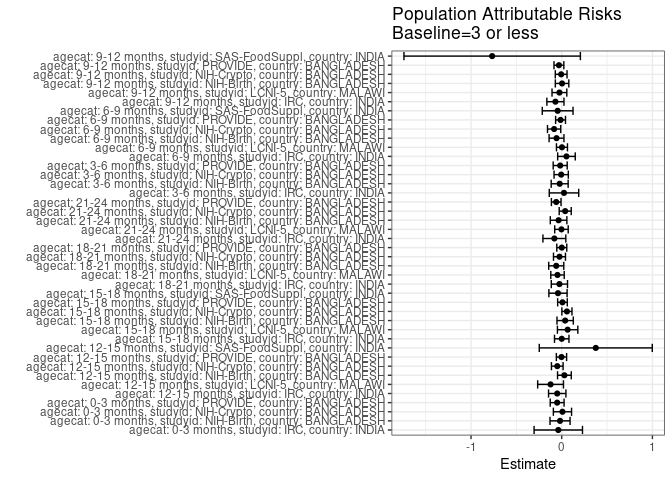

## Results Table

### Parameter: TSM

| agecat | studyid | country | intervention_level | baseline_level | estimate | ci_lower | ci_upper |
| --- | --- | --- | --- | --- | --- | --- | --- |
| 0-3 months | IRC | INDIA | 3 or less | NA | 3.1762234 | 2.8898586 | 3.4625881 |
| 0-3 months | IRC | INDIA | 4-5 | NA | 3.1267672 | 2.9549794 | 3.2985549 |
| 0-3 months | IRC | INDIA | 6-7 | NA | 3.2911073 | 3.0508388 | 3.5313757 |
| 0-3 months | IRC | INDIA | 8+ | NA | 2.9424368 | 2.7245272 | 3.1603464 |
| 0-3 months | NIH-Birth | BANGLADESH | 3 or less | NA | 3.1287901 | 3.0081256 | 3.2494546 |
| 0-3 months | NIH-Birth | BANGLADESH | 4-5 | NA | 3.0679745 | 2.9893868 | 3.1465621 |
| 0-3 months | NIH-Birth | BANGLADESH | 6-7 | NA | 3.1136356 | 2.9935721 | 3.2336992 |
| 0-3 months | NIH-Birth | BANGLADESH | 8+ | NA | 3.1916271 | 3.0582528 | 3.3250013 |
| 0-3 months | NIH-Crypto | BANGLADESH | 3 or less | NA | 3.1211391 | 3.0094784 | 3.2327997 |
| 0-3 months | NIH-Crypto | BANGLADESH | 4-5 | NA | 3.1201554 | 3.0679074 | 3.1724033 |
| 0-3 months | NIH-Crypto | BANGLADESH | 6-7 | NA | 3.1204903 | 3.0466381 | 3.1943426 |
| 0-3 months | NIH-Crypto | BANGLADESH | 8+ | NA | 3.1734112 | 3.0902006 | 3.2566217 |
| 0-3 months | PROVIDE | BANGLADESH | 3 or less | NA | 3.3081767 | 3.2231883 | 3.3931651 |
| 0-3 months | PROVIDE | BANGLADESH | 4-5 | NA | 3.2520253 | 3.1980320 | 3.3060186 |
| 0-3 months | PROVIDE | BANGLADESH | 6-7 | NA | 3.2341964 | 3.1524931 | 3.3158997 |
| 0-3 months | PROVIDE | BANGLADESH | 8+ | NA | 3.2418815 | 3.1427100 | 3.3410530 |
| 3-6 months | IRC | INDIA | 3 or less | NA | 1.8557049 | 1.6789502 | 2.0324597 |
| 3-6 months | IRC | INDIA | 4-5 | NA | 1.8635369 | 1.7631241 | 1.9639496 |
| 3-6 months | IRC | INDIA | 6-7 | NA | 1.8428990 | 1.7307262 | 1.9550718 |
| 3-6 months | IRC | INDIA | 8+ | NA | 1.9764948 | 1.8224050 | 2.1305845 |
| 3-6 months | NIH-Birth | BANGLADESH | 3 or less | NA | 1.8554196 | 1.7566027 | 1.9542365 |
| 3-6 months | NIH-Birth | BANGLADESH | 4-5 | NA | 1.7716974 | 1.6957499 | 1.8476449 |
| 3-6 months | NIH-Birth | BANGLADESH | 6-7 | NA | 1.9068145 | 1.8026687 | 2.0109602 |
| 3-6 months | NIH-Birth | BANGLADESH | 8+ | NA | 1.8590372 | 1.7486418 | 1.9694326 |
| 3-6 months | NIH-Crypto | BANGLADESH | 3 or less | NA | 2.0117773 | 1.9289417 | 2.0946129 |
| 3-6 months | NIH-Crypto | BANGLADESH | 4-5 | NA | 1.9957662 | 1.9441400 | 2.0473923 |
| 3-6 months | NIH-Crypto | BANGLADESH | 6-7 | NA | 2.0531598 | 1.9670619 | 2.1392576 |
| 3-6 months | NIH-Crypto | BANGLADESH | 8+ | NA | 1.9609778 | 1.8718051 | 2.0501504 |
| 3-6 months | PROVIDE | BANGLADESH | 3 or less | NA | 1.9827036 | 1.8967759 | 2.0686313 |
| 3-6 months | PROVIDE | BANGLADESH | 4-5 | NA | 1.9456864 | 1.8990884 | 1.9922843 |

[output cut: 138 more lines]

### Parameter: E(Y)

| agecat | studyid | country | intervention_level | baseline_level | estimate | ci_lower | ci_upper |
| --- | --- | --- | --- | --- | --- | --- | --- |
| 0-3 months | IRC | INDIA | NA | NA | 3.1382493 | 3.0275242 | 3.2489743 |
| 0-3 months | NIH-Birth | BANGLADESH | NA | NA | 3.1100116 | 3.0566021 | 3.1634210 |
| 0-3 months | NIH-Crypto | BANGLADESH | NA | NA | 3.1292449 | 3.0928504 | 3.1656393 |
| 0-3 months | PROVIDE | BANGLADESH | NA | NA | 3.2576810 | 3.2206777 | 3.2946843 |
| 3-6 months | IRC | INDIA | NA | NA | 1.8806738 | 1.8168757 | 1.9444719 |
| 3-6 months | NIH-Birth | BANGLADESH | NA | NA | 1.8326915 | 1.7846731 | 1.8807099 |
| 3-6 months | NIH-Crypto | BANGLADESH | NA | NA | 2.0057973 | 1.9693775 | 2.0422170 |
| 3-6 months | PROVIDE | BANGLADESH | NA | NA | 1.9657457 | 1.9318660 | 1.9996254 |
| 6-9 months | IRC | INDIA | NA | NA | 1.3724009 | 1.3237927 | 1.4210091 |
| 6-9 months | LCNI-5 | MALAWI | NA | NA | 1.4589363 | 1.4224162 | 1.4954563 |
| 6-9 months | NIH-Birth | BANGLADESH | NA | NA | 1.2555950 | 1.2150667 | 1.2961234 |
| 6-9 months | NIH-Crypto | BANGLADESH | NA | NA | 1.3282695 | 1.2988292 | 1.3577098 |
| 6-9 months | PROVIDE | BANGLADESH | NA | NA | 1.2824185 | 1.2571827 | 1.3076542 |
| 6-9 months | SAS-FoodSuppl | INDIA | NA | NA | 1.1426155 | 1.1021386 | 1.1830923 |
| 9-12 months | IRC | INDIA | NA | NA | 1.1234734 | 1.0841051 | 1.1628417 |
| 9-12 months | LCNI-5 | MALAWI | NA | NA | 1.1007887 | 1.0539615 | 1.1476158 |
| 9-12 months | NIH-Birth | BANGLADESH | NA | NA | 1.0885809 | 1.0534446 | 1.1237171 |
| 9-12 months | NIH-Crypto | BANGLADESH | NA | NA | 1.1234745 | 1.0972274 | 1.1497215 |
| 9-12 months | PROVIDE | BANGLADESH | NA | NA | 1.0499750 | 1.0230130 | 1.0769370 |
| 9-12 months | SAS-FoodSuppl | INDIA | NA | NA | 0.8106649 | 0.6745544 | 0.9467754 |
| 12-15 months | IRC | INDIA | NA | NA | 0.9553539 | 0.9137750 | 0.9969329 |
| 12-15 months | LCNI-5 | MALAWI | NA | NA | 0.9578403 | 0.8612449 | 1.0544357 |
| 12-15 months | NIH-Birth | BANGLADESH | NA | NA | 0.7241623 | 0.6797013 | 0.7686233 |
| 12-15 months | NIH-Crypto | BANGLADESH | NA | NA | 0.9711395 | 0.9465805 | 0.9956985 |
| 12-15 months | PROVIDE | BANGLADESH | NA | NA | 0.9597501 | 0.9335899 | 0.9859102 |
| 12-15 months | SAS-FoodSuppl | INDIA | NA | NA | 1.0267825 | 0.9374856 | 1.1160794 |
| 15-18 months | IRC | INDIA | NA | NA | 0.8591216 | 0.8197594 | 0.8984837 |
| 15-18 months | LCNI-5 | MALAWI | NA | NA | 0.8227868 | 0.7513696 | 0.8942040 |
| 15-18 months | NIH-Birth | BANGLADESH | NA | NA | 0.7727719 | 0.7325606 | 0.8129832 |
| 15-18 months | NIH-Crypto | BANGLADESH | NA | NA | 0.9177168 | 0.8947657 | 0.9406678 |
| 15-18 months | PROVIDE | BANGLADESH | NA | NA | 0.8560998 | 0.8320145 | 0.8801852 |
| 15-18 months | SAS-FoodSuppl | INDIA | NA | NA | 0.7947861 | 0.7590601 | 0.8305122 |
| 18-21 months | IRC | INDIA | NA | NA | 0.7598022 | 0.7214752 | 0.7981291 |
| 18-21 months | LCNI-5 | MALAWI | NA | NA | 0.8198090 | 0.7732927 | 0.8663254 |
| 18-21 months | NIH-Birth | BANGLADESH | NA | NA | 0.7291468 | 0.6930874 | 0.7652062 |
| 18-21 months | NIH-Crypto | BANGLADESH | NA | NA | 0.7977755 | 0.7744353 | 0.8211158 |
| 18-21 months | PROVIDE | BANGLADESH | NA | NA | 0.8393377 | 0.8153485 | 0.8633269 |
| 21-24 months | IRC | INDIA | NA | NA | 0.7084129 | 0.6674749 | 0.7493508 |
| 21-24 months | LCNI-5 | MALAWI | NA | NA | 0.7505036 | 0.7048983 | 0.7961088 |
| 21-24 months | NIH-Birth | BANGLADESH | NA | NA | 0.7172178 | 0.6817161 | 0.7527194 |
| 21-24 months | NIH-Crypto | BANGLADESH | NA | NA | 0.7993353 | 0.7748026 | 0.8238681 |
| 21-24 months | PROVIDE | BANGLADESH | NA | NA | 0.7631391 | 0.7377453 | 0.7885328 |

### Parameter: ATE

| agecat | studyid | country | intervention_level | baseline_level | estimate | ci_lower | ci_upper |
| --- | --- | --- | --- | --- | --- | --- | --- |
| 0-3 months | IRC | INDIA | 3 or less | 3 or less | 0.0000000 | 0.0000000 | 0.0000000 |
| 0-3 months | IRC | INDIA | 4-5 | 3 or less | -0.0494562 | -0.3833960 | 0.2844836 |
| 0-3 months | IRC | INDIA | 6-7 | 3 or less | 0.1148839 | -0.2589259 | 0.4886936 |
| 0-3 months | IRC | INDIA | 8+ | 3 or less | -0.2337866 | -0.5936329 | 0.1260598 |
| 0-3 months | NIH-Birth | BANGLADESH | 3 or less | 3 or less | 0.0000000 | 0.0000000 | 0.0000000 |
| 0-3 months | NIH-Birth | BANGLADESH | 4-5 | 3 or less | -0.0608156 | -0.2048154 | 0.0831842 |
| 0-3 months | NIH-Birth | BANGLADESH | 6-7 | 3 or less | -0.0151545 | -0.1853755 | 0.1550665 |
| 0-3 months | NIH-Birth | BANGLADESH | 8+ | 3 or less | 0.0628370 | -0.1170202 | 0.2426942 |
| 0-3 months | NIH-Crypto | BANGLADESH | 3 or less | 3 or less | 0.0000000 | 0.0000000 | 0.0000000 |
| 0-3 months | NIH-Crypto | BANGLADESH | 4-5 | 3 or less | -0.0009837 | -0.1242637 | 0.1222963 |
| 0-3 months | NIH-Crypto | BANGLADESH | 6-7 | 3 or less | -0.0006487 | -0.1345227 | 0.1332253 |
| 0-3 months | NIH-Crypto | BANGLADESH | 8+ | 3 or less | 0.0522721 | -0.0869834 | 0.1915276 |
| 0-3 months | PROVIDE | BANGLADESH | 3 or less | 3 or less | 0.0000000 | 0.0000000 | 0.0000000 |
| 0-3 months | PROVIDE | BANGLADESH | 4-5 | 3 or less | -0.0561514 | -0.1568406 | 0.0445377 |
| 0-3 months | PROVIDE | BANGLADESH | 6-7 | 3 or less | -0.0739803 | -0.1918720 | 0.0439113 |
| 0-3 months | PROVIDE | BANGLADESH | 8+ | 3 or less | -0.0662952 | -0.1969015 | 0.0643111 |
| 3-6 months | IRC | INDIA | 3 or less | 3 or less | 0.0000000 | 0.0000000 | 0.0000000 |
| 3-6 months | IRC | INDIA | 4-5 | 3 or less | 0.0078319 | -0.1954535 | 0.2111174 |
| 3-6 months | IRC | INDIA | 6-7 | 3 or less | -0.0128059 | -0.2221501 | 0.1965382 |
| 3-6 months | IRC | INDIA | 8+ | 3 or less | 0.1207898 | -0.1137008 | 0.3552805 |
| 3-6 months | NIH-Birth | BANGLADESH | 3 or less | 3 or less | 0.0000000 | 0.0000000 | 0.0000000 |
| 3-6 months | NIH-Birth | BANGLADESH | 4-5 | 3 or less | -0.0837222 | -0.2083529 | 0.0409084 |
| 3-6 months | NIH-Birth | BANGLADESH | 6-7 | 3 or less | 0.0513949 | -0.0921709 | 0.1949606 |
| 3-6 months | NIH-Birth | BANGLADESH | 8+ | 3 or less | 0.0036176 | -0.1445442 | 0.1517794 |
| 3-6 months | NIH-Crypto | BANGLADESH | 3 or less | 3 or less | 0.0000000 | 0.0000000 | 0.0000000 |
| 3-6 months | NIH-Crypto | BANGLADESH | 4-5 | 3 or less | -0.0160111 | -0.1136174 | 0.0815952 |
| 3-6 months | NIH-Crypto | BANGLADESH | 6-7 | 3 or less | 0.0413825 | -0.0780938 | 0.1608588 |
| 3-6 months | NIH-Crypto | BANGLADESH | 8+ | 3 or less | -0.0507995 | -0.1725103 | 0.0709112 |
| 3-6 months | PROVIDE | BANGLADESH | 3 or less | 3 or less | 0.0000000 | 0.0000000 | 0.0000000 |
| 3-6 months | PROVIDE | BANGLADESH | 4-5 | 3 or less | -0.0370172 | -0.1347666 | 0.0607321 |

[output cut: 138 more lines]

### Parameter: PAR

| agecat | studyid | country | intervention_level | baseline_level | estimate | ci_lower | ci_upper |
| --- | --- | --- | --- | --- | --- | --- | --- |
| 0-3 months | IRC | INDIA | 3 or less | NA | -0.0379741 | -0.3048220 | 0.2288737 |
| 0-3 months | NIH-Birth | BANGLADESH | 3 or less | NA | -0.0187785 | -0.1293054 | 0.0917484 |
| 0-3 months | NIH-Crypto | BANGLADESH | 3 or less | NA | 0.0081058 | -0.0921808 | 0.1083925 |
| 0-3 months | PROVIDE | BANGLADESH | 3 or less | NA | -0.0504957 | -0.1267579 | 0.0257665 |
| 3-6 months | IRC | INDIA | 3 or less | NA | 0.0249689 | -0.1373305 | 0.1872684 |
| 3-6 months | NIH-Birth | BANGLADESH | 3 or less | NA | -0.0227281 | -0.1162544 | 0.0707982 |
| 3-6 months | NIH-Crypto | BANGLADESH | 3 or less | NA | -0.0059800 | -0.0846807 | 0.0727206 |
| 3-6 months | PROVIDE | BANGLADESH | 3 or less | NA | -0.0169579 | -0.0941797 | 0.0602639 |
| 6-9 months | IRC | INDIA | 3 or less | NA | 0.0521428 | -0.0448066 | 0.1490921 |
| 6-9 months | LCNI-5 | MALAWI | 3 or less | NA | 0.0025910 | -0.0580346 | 0.0632166 |
| 6-9 months | NIH-Birth | BANGLADESH | 3 or less | NA | -0.0574971 | -0.1394727 | 0.0244785 |
| 6-9 months | NIH-Crypto | BANGLADESH | 3 or less | NA | -0.0839579 | -0.1569600 | -0.0109559 |
| 6-9 months | PROVIDE | BANGLADESH | 3 or less | NA | -0.0129953 | -0.0674288 | 0.0414382 |
| 6-9 months | SAS-FoodSuppl | INDIA | 3 or less | NA | -0.0449831 | -0.2145590 | 0.1245928 |
| 9-12 months | IRC | INDIA | 3 or less | NA | -0.0696264 | -0.1638728 | 0.0246200 |
| 9-12 months | LCNI-5 | MALAWI | 3 or less | NA | -0.0255355 | -0.1070459 | 0.0559748 |
| 9-12 months | NIH-Birth | BANGLADESH | 3 or less | NA | 0.0038492 | -0.0705163 | 0.0782147 |
| 9-12 months | NIH-Crypto | BANGLADESH | 3 or less | NA | -0.0062146 | -0.0708543 | 0.0584252 |
| 9-12 months | PROVIDE | BANGLADESH | 3 or less | NA | -0.0310303 | -0.0852776 | 0.0232170 |
| 9-12 months | SAS-FoodSuppl | INDIA | 3 or less | NA | -0.7670990 | -1.7398023 | 0.2056043 |
| 12-15 months | IRC | INDIA | 3 or less | NA | -0.0495334 | -0.1452750 | 0.0462081 |
| 12-15 months | LCNI-5 | MALAWI | 3 or less | NA | -0.1230540 | -0.2652997 | 0.0191916 |
| 12-15 months | NIH-Birth | BANGLADESH | 3 or less | NA | 0.0295486 | -0.0461047 | 0.1052019 |
| 12-15 months | NIH-Crypto | BANGLADESH | 3 or less | NA | -0.0491593 | -0.1134001 | 0.0150815 |
| 12-15 months | PROVIDE | BANGLADESH | 3 or less | NA | -0.0027858 | -0.0592932 | 0.0537215 |
| 12-15 months | SAS-FoodSuppl | INDIA | 3 or less | NA | 0.3753632 | -0.2477448 | 0.9984712 |
| 15-18 months | IRC | INDIA | 3 or less | NA | 0.0001139 | -0.0795835 | 0.0798112 |
| 15-18 months | LCNI-5 | MALAWI | 3 or less | NA | 0.0650540 | -0.0474351 | 0.1775432 |
| 15-18 months | NIH-Birth | BANGLADESH | 3 or less | NA | 0.0376842 | -0.0523576 | 0.1277259 |
| 15-18 months | NIH-Crypto | BANGLADESH | 3 or less | NA | 0.0572834 | 0.0015445 | 0.1130222 |
| 15-18 months | PROVIDE | BANGLADESH | 3 or less | NA | 0.0081546 | -0.0449603 | 0.0612695 |
| 15-18 months | SAS-FoodSuppl | INDIA | 3 or less | NA | -0.0412186 | -0.1416590 | 0.0592218 |
| 18-21 months | IRC | INDIA | 3 or less | NA | -0.0257186 | -0.1150991 | 0.0636619 |
| 18-21 months | LCNI-5 | MALAWI | 3 or less | NA | -0.0466035 | -0.1205949 | 0.0273880 |
| 18-21 months | NIH-Birth | BANGLADESH | 3 or less | NA | -0.0604485 | -0.1435731 | 0.0226762 |
| 18-21 months | NIH-Crypto | BANGLADESH | 3 or less | NA | -0.0248581 | -0.0908699 | 0.0411537 |
| 18-21 months | PROVIDE | BANGLADESH | 3 or less | NA | 0.0006334 | -0.0543212 | 0.0555879 |
| 21-24 months | IRC | INDIA | 3 or less | NA | -0.0812195 | -0.2073486 | 0.0449096 |
| 21-24 months | LCNI-5 | MALAWI | 3 or less | NA | -0.0030516 | -0.0774816 | 0.0713784 |
| 21-24 months | NIH-Birth | BANGLADESH | 3 or less | NA | -0.0346708 | -0.1259526 | 0.0566110 |
| 21-24 months | NIH-Crypto | BANGLADESH | 3 or less | NA | 0.0384005 | -0.0278538 | 0.1046548 |
| 21-24 months | PROVIDE | BANGLADESH | 3 or less | NA | -0.0608232 | -0.1138107 | -0.0078358 |